# Analysis of the U.S. National Oceanic and Atmospheric Administration’s (NOAA) storm database

Soham Saha

7/23/2020

## Introduction

Storms and other severe weather events can cause both public health and economic problems for communities and municipalities. Many severe events can result in fatalities, injuries, and property damage, and preventing such outcomes to the extent possible is a key concern.

## Data

The raw data file for this assignment come in the form of a csv file compressed and downloadable from the website as follows:

```r
# download data from the link
Url_data <- "https://d396qusza40orc.cloudfront.net/repdata%2Fdata%2FStormData.csv.bz2"

File_data <- "StormData.csv.bz2"
if (!file.exists(File_data)) {
  download.file(Url_data, File_data, mode = "wb")
}
```

There is also some documentation of the database available. Here you will find how some of the variables are constructed/defined. - [National Weather Service Storm Data Documentation](https://d396qusza40orc.cloudfront.net/repdata%2Fpeer2_doc%2Fpd01016005curr.pdf) - [National Climatic Data Center Storm Events FAQ](https://d396qusza40orc.cloudfront.net/repdata%2Fpeer2_doc%2FNCDC%20Storm%20Events-FAQ%20Page.pdf) - [Mentor’s comments in the Discussion Forum on the Course web-site](https://www.coursera.org/learn/reproducible-research/discussions/weeks/4/threads/IdtP_JHzEeaePQ71AQUtYw)

## Environment Data Processing

The data is first read in RStudio using the R command:

```r
# reading data
data <- read.csv(file = File_data, header=TRUE, sep=",")
head(data)
```

[output not shown]

The data recording start from Jan. 1950 in the NOAA. Only TORNADOES were events recorded from 1950 till 1996, when more events were gradually added. We consider and include events that started from 1996.

```r
# date subsets
Main_data <- data
Main_data$BGN_DATE <- strptime(data$BGN_DATE, "%m/%d/%Y %H:%M:%S")
Main_data <- subset(Main_data, BGN_DATE > "1995-12-31")
```

Further we subset the data based on the required variables for our analysis, namely EVTYPE, FATALITIES, INJURIES, PROPDMG, PROPDMGEXP, CROPDMG, CROPDMGEXP. We limit our data to these variables.

```r
# subsetting to required columns
Main_data <- subset(Main_data, select = c(EVTYPE, FATALITIES, INJURIES, PROPDMG, PROPDMGEXP, CROPDMG, CROPDMGEXP))
#main event types
length(unique(Main_data$EVTYPE))
```

```
## [1] 516
```

```r
#cleaning event types names
Main_data$EVTYPE <- toupper(Main_data$EVTYPE)
# eliminating zero data
Main_data <- Main_data[Main_data$FATALITIES !=0 |
                         Main_data$INJURIES !=0 |
                         Main_data$PROPDMG !=0 |
                         Main_data$CROPDMG !=0, ]
length(unique(Main_data$EVTYPE))
```

```
## [1] 186
```

Now we have reduced and cleaned our dataset to 186 unique event types.

## Population Health Data Processing

```r
#Population health data pre-process
Health_data <- aggregate(cbind(FATALITIES, INJURIES) ~ EVTYPE, data = Main_data, FUN=sum)
Health_data$PEOPLE_LOSS <- Health_data$FATALITIES + Health_data$INJURIES
Health_data <- Health_data[order(Health_data$PEOPLE_LOSS, decreasing = TRUE), ]
Top15_events_people <- Health_data[1:15,]
knitr::kable(Top15_events_people, format = "markdown")
```

|  | EVTYPE | FATALITIES | INJURIES | PEOPLE_LOSS |
| --- | --- | --- | --- | --- |
| 149 | TORNADO | 1511 | 20667 | 22178 |
| 39 | EXCESSIVE HEAT | 1797 | 6391 | 8188 |
| 48 | FLOOD | 414 | 6758 | 7172 |
| 107 | LIGHTNING | 651 | 4141 | 4792 |
| 153 | TSTM WIND | 241 | 3629 | 3870 |
| 46 | FLASH FLOOD | 887 | 1674 | 2561 |
| 146 | THUNDERSTORM WIND | 130 | 1400 | 1530 |
| 182 | WINTER STORM | 191 | 1292 | 1483 |
| 69 | HEAT | 237 | 1222 | 1459 |
| 88 | HURRICANE/TYPHOON | 64 | 1275 | 1339 |
| 83 | HIGH WIND | 235 | 1083 | 1318 |
| 177 | WILDFIRE | 75 | 911 | 986 |
| 74 | HEAVY SNOW | 107 | 698 | 805 |
| 50 | FOG | 60 | 712 | 772 |
| 66 | HAIL | 7 | 713 | 720 |

The number/letter in the exponent value columns (PROPDMGEXP and CROPDMGEXP) represents the power of ten (10^The number). It means that the total size of damage is the product of PROPDMG and CROPDMG and figure 10 in the power corresponding to exponent value. Exponent values are: - numbers from one to ten  
- letters (B or b = Billion, M or m = Million, K or k = Thousand, H or h = Hundred)  
- and symbols “-”, “+” and “?” which refers to less than, greater than and low certainty. We have the option to ignore these three symbols altogether. We transform letters and symbols to numbers:

```r
#transforming letters and symbols to numbers
Main_data$PROPDMGEXP <- gsub("[Hh]", "2", Main_data$PROPDMGEXP)
Main_data$PROPDMGEXP <- gsub("[Kk]", "3", Main_data$PROPDMGEXP)
Main_data$PROPDMGEXP <- gsub("[Mm]", "6", Main_data$PROPDMGEXP)
Main_data$PROPDMGEXP <- gsub("[Bb]", "9", Main_data$PROPDMGEXP)
Main_data$PROPDMGEXP <- gsub("\\+", "1", Main_data$PROPDMGEXP)
Main_data$PROPDMGEXP <- gsub("\\?|\\-|\\ ", "0",  Main_data$PROPDMGEXP)
Main_data$PROPDMGEXP <- as.numeric(Main_data$PROPDMGEXP)

Main_data$CROPDMGEXP <- gsub("[Hh]", "2", Main_data$CROPDMGEXP)
Main_data$CROPDMGEXP <- gsub("[Kk]", "3", Main_data$CROPDMGEXP)
Main_data$CROPDMGEXP <- gsub("[Mm]", "6", Main_data$CROPDMGEXP)
Main_data$CROPDMGEXP <- gsub("[Bb]", "9", Main_data$CROPDMGEXP)
Main_data$CROPDMGEXP <- gsub("\\+", "1", Main_data$CROPDMGEXP)
Main_data$CROPDMGEXP <- gsub("\\-|\\?|\\ ", "0", Main_data$CROPDMGEXP)
Main_data$CROPDMGEXP <- as.numeric(Main_data$CROPDMGEXP)

Main_data$PROPDMGEXP[is.na(Main_data$PROPDMGEXP)] <- 0
Main_data$CROPDMGEXP[is.na(Main_data$CROPDMGEXP)] <- 0
```

At last, using the ‘dplr’ package, we create the final data-table for the damages.

```r
#creating total damage values
library(dplyr)
Main_data <- mutate(Main_data,
                    PROPDMGTOTAL = PROPDMG * (10 ^ PROPDMGEXP),
                    CROPDMGTOTAL = CROPDMG * (10 ^ CROPDMGEXP))
#economic data aggregate
Economic_data <- aggregate(cbind(PROPDMGTOTAL, CROPDMGTOTAL) ~ EVTYPE, data = Main_data, FUN=sum)
Economic_data$ECONOMIC_LOSS <- Economic_data$PROPDMGTOTAL + Economic_data$CROPDMGTOTAL
Economic_data <- Economic_data[order(Economic_data$ECONOMIC_LOSS, decreasing = TRUE), ]
Top15_events_economy <- Economic_data[1:15,]
knitr::kable(Top15_events_economy, format = "markdown")
```

|  | EVTYPE | PROPDMGTOTAL | CROPDMGTOTAL | ECONOMIC_LOSS |
| --- | --- | --- | --- | --- |
| 48 | FLOOD | 143944833550 | 4974778400 | 148919611950 |
| 88 | HURRICANE/TYPHOON | 69305840000 | 2607872800 | 71913712800 |
| 141 | STORM SURGE | 43193536000 | 5000 | 43193541000 |
| 149 | TORNADO | 24616945710 | 283425010 | 24900370720 |
| 66 | HAIL | 14595143420 | 2476029450 | 17071172870 |
| 46 | FLASH FLOOD | 15222203910 | 1334901700 | 16557105610 |
| 86 | HURRICANE | 11812819010 | 2741410000 | 14554229010 |
| 32 | DROUGHT | 1046101000 | 13367566000 | 14413667000 |
| 152 | TROPICAL STORM | 7642475550 | 677711000 | 8320186550 |
| 83 | HIGH WIND | 5247860360 | 633561300 | 5881421660 |
| 177 | WILDFIRE | 4758667000 | 295472800 | 5054139800 |
| 153 | TSTM WIND | 4478056440 | 553915350 | 5031971790 |
| 142 | STORM SURGE/TIDE | 4641188000 | 850000 | 4642038000 |
| 146 | THUNDERSTORM WIND | 3382654440 | 398331000 | 3780985440 |
| 94 | ICE STORM | 3642248810 | 15660000 | 3657908810 |

## Results

Analyzing population health impact on the graph one can conclude that TORNADOS, EXCESSIVE HEAT, FLOOD, LIGHTNING and TSTM WIND are the main contributors to deaths and injuries out of all event types of weather events. We show the top 15 weather events:

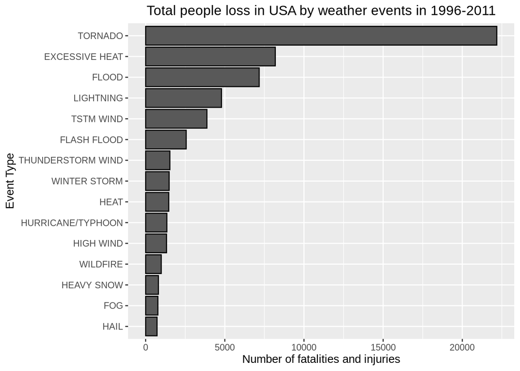

```r
#plotting health loss
library(ggplot2)
g <- ggplot(data = Top15_events_people, aes(x = reorder(EVTYPE, PEOPLE_LOSS), y = PEOPLE_LOSS))
g <- g + geom_bar(stat = "identity", colour = "black")
g <- g + labs(title = "Total people loss in USA by weather events in 1996-2011")
g <- g + theme(plot.title = element_text(hjust = 0.5))
g <- g + labs(y = "Number of fatalities and injuries", x = "Event Type")
g <- g + coord_flip()
print(g)
```

Analyzing economic impact on the graph one can conclude that FLOOD, HURRICANE/TYPHOON and STORM SURGE are the main contributors to severe economic consequences out of all event types of weather events.

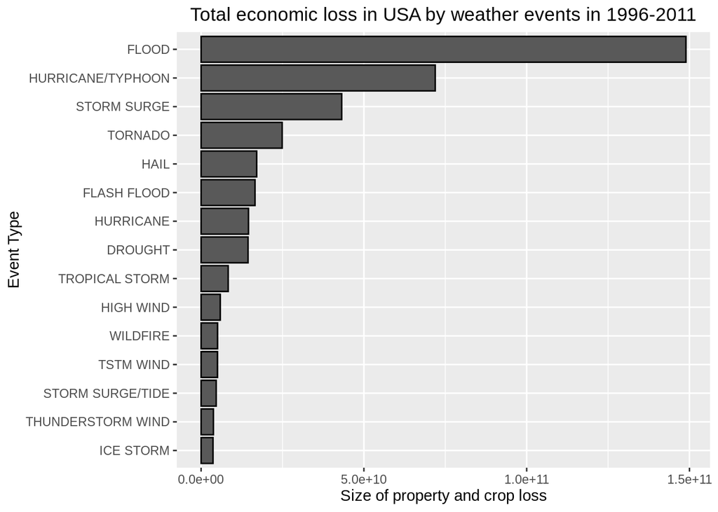

```r
#plotting economic loss
g <- ggplot(data = Top15_events_economy, aes(x = reorder(EVTYPE, ECONOMIC_LOSS), y = ECONOMIC_LOSS))
g <- g + geom_bar(stat = "identity", colour = "black")
g <- g + labs(title = "Total economic loss in USA by weather events in 1996-2011")
g <- g + theme(plot.title = element_text(hjust = 0.5))
g <- g + labs(y = "Size of property and crop loss", x = "Event Type")
g <- g + coord_flip()
print(g)
```

Furthermore, we isolated the common causes of economic and weather deaths and show a relationship between the two:

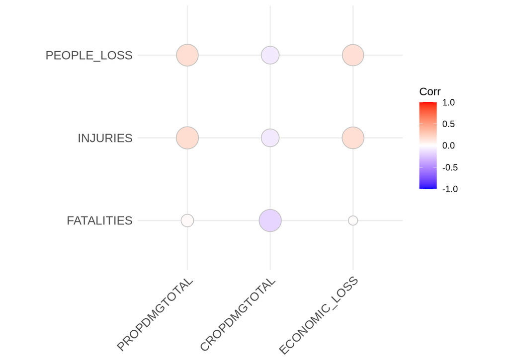

```r
#correlate health and economic loss
library(ggcorrplot)
library(corrplot)
library(Hmisc)
merged_data = merge(Top15_events_economy, Top15_events_people, by.x = "EVTYPE")
mc_data <- merged_data[,2:length(merged_data)]
corr = round(cor(mc_data),2)

ggcorrplot(corr[1:3,4:6], method = "circle")
```